# Explore_bikeshare_data

### Explore Bike Share Data

For this project, your goal is to ask and answer three questions about the available bikeshare data from Washington, Chicago, and New York. This notebook can be submitted directly through the workspace when you are confident in your results.

You will be graded against the project [Rubric](https://review.udacity.com/#!/rubrics/2508/view) by a mentor after you have submitted. To get you started, you can use the template below, but feel free to be creative in your solutions!

```r
library(ggplot2)
```

```r
ny = read.csv('new_york_city.csv')
wash = read.csv('washington.csv')
chi = read.csv('chicago.csv')
```

```r
head(ny)
```

| X | Start.Time | End.Time | Trip.Duration | Start.Station | End.Station | User.Type | Gender | Birth.Year |
| --- | --- | --- | --- | --- | --- | --- | --- | --- |
| 5688089 | 2017-06-11 14:55:05 | 2017-06-11 15:08:21 | 795 | Suffolk St & Stanton St | W Broadway & Spring St | Subscriber | Male | 1998 |
| 4096714 | 2017-05-11 15:30:11 | 2017-05-11 15:41:43 | 692 | Lexington Ave & E 63 St | 1 Ave & E 78 St | Subscriber | Male | 1981 |
| 2173887 | 2017-03-29 13:26:26 | 2017-03-29 13:48:31 | 1325 | 1 Pl & Clinton St | Henry St & Degraw St | Subscriber | Male | 1987 |
| 3945638 | 2017-05-08 19:47:18 | 2017-05-08 19:59:01 | 703 | Barrow St & Hudson St | W 20 St & 8 Ave | Subscriber | Female | 1986 |
| 6208972 | 2017-06-21 07:49:16 | 2017-06-21 07:54:46 | 329 | 1 Ave & E 44 St | E 53 St & 3 Ave | Subscriber | Male | 1992 |
| 1285652 | 2017-02-22 18:55:24 | 2017-02-22 19:12:03 | 998 | State St & Smith St | Bond St & Fulton St | Subscriber | Male | 1986 |

```r
#Visualizing a small subset sample to identify any patterns/missing data
sample(ny)
```

[output not shown]

```r
#Checking for null values
apply(is.na(ny), 2, sum)
```

**X**

0

**Start.Time**

0

**End.Time**

0

**Trip.Duration**

1

**Start.Station**

0

**End.Station**

0

**User.Type**

0

**Gender**

0

**Birth.Year**

5218

**months**

0

```r
#Checking for null values
ny %>% summarise_all(funs(sum(is.na(.))))
```

[output not shown]

```r
head(wash)
```

| X | Start.Time | End.Time | Trip.Duration | Start.Station | End.Station | User.Type |
| --- | --- | --- | --- | --- | --- | --- |
| 1621326 | 2017-06-21 08:36:34 | 2017-06-21 08:44:43 | 489.066 | 14th & Belmont St NW | 15th & K St NW | Subscriber |
| 482740 | 2017-03-11 10:40:00 | 2017-03-11 10:46:00 | 402.549 | Yuma St & Tenley Circle NW | Connecticut Ave & Yuma St NW | Subscriber |
| 1330037 | 2017-05-30 01:02:59 | 2017-05-30 01:13:37 | 637.251 | 17th St & Massachusetts Ave NW | 5th & K St NW | Subscriber |
| 665458 | 2017-04-02 07:48:35 | 2017-04-02 08:19:03 | 1827.341 | Constitution Ave & 2nd St NW/DOL | M St & Pennsylvania Ave NW | Customer |
| 1481135 | 2017-06-10 08:36:28 | 2017-06-10 09:02:17 | 1549.427 | Henry Bacon Dr & Lincoln Memorial Circle NW | Maine Ave & 7th St SW | Subscriber |
| 1148202 | 2017-05-14 07:18:18 | 2017-05-14 07:24:56 | 398.000 | 1st & K St SE | Eastern Market Metro / Pennsylvania Ave & 7th St SE | Subscriber |

```r
#Visualizing a small subset sample to identify any patterns/missing data
sample(wash)
```

[output not shown]

```r
#Checking for null values in wash dataset
apply(is.na(wash), 2, sum)
```

**X**

1

**Start.Time**

1

**End.Time**

1

**Trip.Duration**

1

**Start.Station**

1

**End.Station**

1

**User.Type**

1

**months**

1

```r
#Checking for null values
wash %>% summarise_all(funs(sum(is.na(.))))
```

[output not shown]

```r
head(chi)
```

| X | Start.Time | End.Time | Trip.Duration | Start.Station | End.Station | User.Type | Gender | Birth.Year |
| --- | --- | --- | --- | --- | --- | --- | --- | --- |
| 1423854 | 2017-06-23 15:09:32 | 2017-06-23 15:14:53 | 321 | Wood St & Hubbard St | Damen Ave & Chicago Ave | Subscriber | Male | 1992 |
| 955915 | 2017-05-25 18:19:03 | 2017-05-25 18:45:53 | 1610 | Theater on the Lake | Sheffield Ave & Waveland Ave | Subscriber | Female | 1992 |
| 9031 | 2017-01-04 08:27:49 | 2017-01-04 08:34:45 | 416 | May St & Taylor St | Wood St & Taylor St | Subscriber | Male | 1981 |
| 304487 | 2017-03-06 13:49:38 | 2017-03-06 13:55:28 | 350 | Christiana Ave & Lawrence Ave | St. Louis Ave & Balmoral Ave | Subscriber | Male | 1986 |
| 45207 | 2017-01-17 14:53:07 | 2017-01-17 15:02:01 | 534 | Clark St & Randolph St | Desplaines St & Jackson Blvd | Subscriber | Male | 1975 |
| 1473887 | 2017-06-26 09:01:20 | 2017-06-26 09:11:06 | 586 | Clinton St & Washington Blvd | Canal St & Taylor St | Subscriber | Male | 1990 |

```r
#Visualizing a small subset sample to identify any patterns/missing data
sample(chi)
```

[output not shown]

```r
#Checking for null values
apply(is.na(chi), 2, sum)
```

**X**

0

**Start.Time**

0

**End.Time**

0

**Trip.Duration**

0

**Start.Station**

0

**End.Station**

0

**User.Type**

0

**Gender**

0

**Birth.Year**

1747

**months**

0

```r
#Checking for null values
chi %>% summarise_all(funs(sum(is.na(.))))
```

[output not shown]

```r
sapply(list("Chicago" = chi,"New York" = ny,"Washington" = wash), glimpse)
```

```
Observations: 8,630
Variables: 9
$ X             <int> 1423854, 955915, 9031, 304487, 45207, 1473887, 961916, …
$ Start.Time    <fct> 2017-06-23 15:09:32, 2017-05-25 18:19:03, 2017-01-04 08…
$ End.Time      <fct> 2017-06-23 15:14:53, 2017-05-25 18:45:53, 2017-01-04 08…
$ Trip.Duration <int> 321, 1610, 416, 350, 534, 586, 281, 723, 689, 493, 301,…
$ Start.Station <fct> Wood St & Hubbard St, Theater on the Lake, May St & Tay…
$ End.Station   <fct> Damen Ave & Chicago Ave, Sheffield Ave & Waveland Ave, …
$ User.Type     <fct> Subscriber, Subscriber, Subscriber, Subscriber, Subscri…
$ Gender        <fct> Male, Female, Male, Male, Male, Male, Female, , Male, M…
$ Birth.Year    <dbl> 1992, 1992, 1981, 1986, 1975, 1990, 1983, NA, 1984, 197…
Observations: 54,770
Variables: 9
$ X             <int> 5688089, 4096714, 2173887, 3945638, 6208972, 1285652, 1…
$ Start.Time    <fct> 2017-06-11 14:55:05, 2017-05-11 15:30:11, 2017-03-29 13…
```

[output cut: 16 more lines]

**$Chicago**

[output not shown]

**$`New York`**

[output not shown]

**$Washington**

[output not shown]

```r
#Summary statistics for each dataset
sapply(list("Chicago" = chi,"New York" = ny,"Washington"  =  wash), summary)
```

```
$Chicago
       X                         Start.Time                  End.Time
 Min.   :     36   2017-01-24 07:40:32:   2   2017-04-16 13:16:52:   2
 1st Qu.: 386722   2017-04-22 13:16:25:   2   2017-04-26 16:29:26:   2
 Median : 773554   2017-05-27 15:17:50:   2   2017-05-21 16:20:56:   2
 Mean   : 776721   2017-06-10 13:29:41:   2   2017-05-27 09:58:21:   2
 3rd Qu.:1171266   2017-06-20 17:05:11:   2   2017-06-25 14:51:35:   2
 Max.   :1551248   2017-06-21 13:18:52:   2   2017-01-01 00:46:32:   1
                   (Other)            :8618   (Other)            :8619
 Trip.Duration                          Start.Station
 Min.   :   60.0   Streeter Dr & Grand Ave     : 210
 1st Qu.:  394.2   Lake Shore Dr & Monroe St   : 140
 Median :  670.0   Clinton St & Washington Blvd: 120
 Mean   :  937.2   Clinton St & Madison St     : 102
 3rd Qu.: 1119.0   Canal St & Adams St         : 101
 Max.   :85408.0   Michigan Ave & Oak St       :  98
                   (Other)                     :7859
                       End.Station        User.Type       Gender
 Streeter Dr & Grand Ave     : 233             :   1         :1748
 Clinton St & Madison St     : 145   Customer  :1746   Female:1723
 Theater on the Lake         : 131   Subscriber:6883   Male  :5159
 Lake Shore Dr & Monroe St   : 115
 Clinton St & Washington Blvd: 109
 Lake Shore Dr & North Blvd  : 102
 (Other)                     :7795
   Birth.Year
 Min.   :1899
 1st Qu.:1975
 Median :1984
 Mean   :1981
 3rd Qu.:1989
 Max.   :2002
 NA's   :1747

$`New York`
       X                         Start.Time                   End.Time
 Min.   :     47   2017-05-11 18:26:10:    3   2017-01-03 08:54:10:    2
 1st Qu.:1712425   2017-01-04 13:58:24:    2   2017-01-04 17:21:55:    2
 Median :3418634   2017-01-09 09:36:01:    2   2017-01-05 17:25:17:    2
 Mean   :3415873   2017-01-21 15:36:56:    2   2017-01-12 08:34:01:    2
```

[output cut: 34 more lines]

```
 3rd Qu.:  1233.2   Jefferson Memorial                  : 1068
 Max.   :904591.4   15th & P St NW                      : 1040
 NA's   :1          (Other)                             :80990
                                                End.Station
 Columbus Circle / Union Station                      : 1767
 Jefferson Dr & 14th St SW                            : 1603
 Lincoln Memorial                                     : 1514
 Massachusetts Ave & Dupont Circle NW                 : 1344
 Smithsonian-National Mall / Jefferson Dr & 12th St SW: 1103
 15th & P St NW                                       : 1077
 (Other)                                              :80643
      User.Type
           :    1
 Customer  :23450
 Subscriber:65600
```

### Question 1

What months are the busiest for each city?

```r
# Your solution code goes here
```

The as.Date function is used to convert the values in the Start.Time column to dates. The months function is used to extract the month names from the dates. The abbreviate argument is set to TRUE, which means that the month names will be abbreviated (e.g., "Jan" for January). The month names are then assigned to the months column in each of the data frames using the assignment operator <-.

```r
#The as.Date function is used to convert the values in the Start.Time column to dates.
#The months function is used to extract the month names from the dates.
#The abbreviate argument is set to TRUE, which means that the month names will be abbreviated (e.g., "Jan" for January).
#The month names are then assigned to the months column in each of the data frames using the assignment operator <-.
ny$months <- months(as.Date(ny$Start.Time), abbreviate=TRUE)
wash$months <- months(as.Date(wash$Start.Time), abbreviate=TRUE)
chi$months <- months(as.Date(chi$Start.Time), abbreviate=TRUE)
```

```r
#Creates labels for the columns
ny$months <- factor(ny$months, levels = c("Jan", "Feb", "Mar", "Apr", "May","Jun"))
wash$months <- factor(wash$months, levels = c("Jan", "Feb", "Mar", "Apr","May", "Jun"))
chi$months <- factor(chi$months, levels = c("Jan", "Feb", "Mar", "Apr", "May", "Jun"))
```

```r
#Creates table summary for New York by month
table(ny$months)
```

```
  Jan   Feb   Mar   Apr   May   Jun
 5745  6364  5820 10661 12180 14000
```

```r
#Creates table summary for Washington, DC by month
table(wash$months)
```

```
  Jan   Feb   Mar   Apr   May   Jun
 8946 11563 12612 18522 17072 20335
```

```r
#Creates table summary for Chicago by month
table(chi$months)
```

```
 Jan  Feb  Mar  Apr  May  Jun
 650  930  803 1526 1905 2816
```

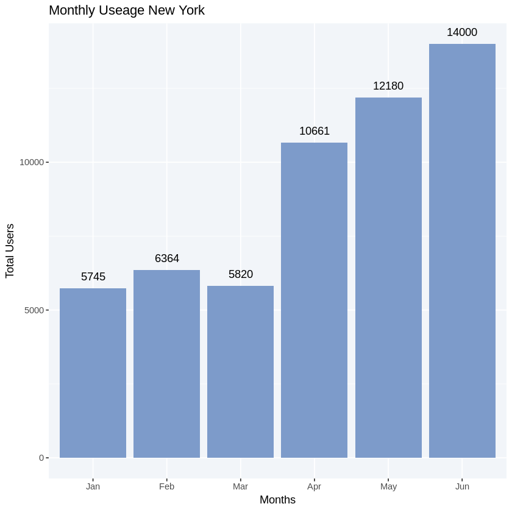

```r
#Bar chart showing the Monthly Useage for New York City
ny_usage <- ggplot(ny, aes(x=ny$months)) +
  geom_bar(stat="count", fill = "#7D9BCA") +   geom_text(
    stat = "count",
    aes(label = ..count..), vjust = -1,
  ) +
labs(x = "Months", y = "Total Users", title = "Monthly Useage New York") +
theme(panel.background = element_rect(fill = "#f2f5f9"), text = element_text(color = "Black"))
ny_usage
```

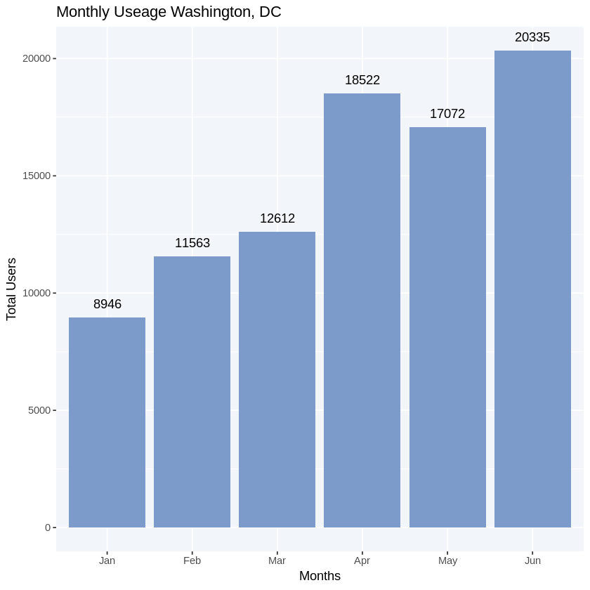

```r
#Bar chart showing the Monthly Useage for Washington DC
wash <- dplyr::filter(wash, !is.na(months))

wash_usage <- ggplot(wash, aes(x=wash$months)) +
  geom_bar(stat="count", fill = "#7D9BCA") +   geom_text(
    stat = "count",
    aes(label = ..count..), vjust = -1,
  ) +
labs(x = "Months", y = "Total Users", title = "Monthly Useage Washington, DC") +
theme(panel.background = element_rect(fill = "#f2f5f9"), text = element_text(color = "Black"))
wash_usage
```

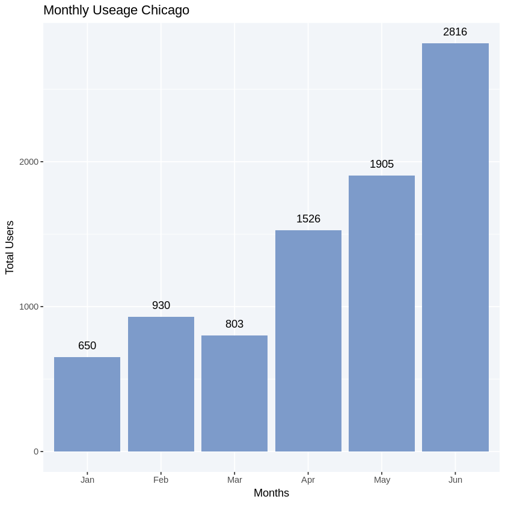

```r
chi_usage  <- ggplot(chi, aes(x=chi$months)) +
  geom_bar(stat="count", fill = "#7D9BCA") +   geom_text(
    stat = "count",
    aes(label = ..count..), vjust = -1,
  ) +
labs(x = "Months", y = "Total Users", title = "Monthly Useage Chicago") +
theme(panel.background = element_rect(fill = "#f2f5f9"), text = element_text(color = "Black"))
chi_usage
```

**Summary of your question 1 results goes here.**  
For each city June was the busiest month for bike rentals.  
New York had 14,000 users in June, Washington, DC had 20,335 in June and Chicago had 2,816 in June

### Question 2

What is the user breakdown of people renting bikes. Are they subscribers to the service or single ride customers?

```r
# Your solution code goes here
```

```r
table(ny$User.Type)
```

```
             Customer Subscriber
       119       5558      49093
```

```r
prop.table(table(ny$User.Type))
```

```
               Customer  Subscriber
0.002172722 0.101478912 0.896348366
```

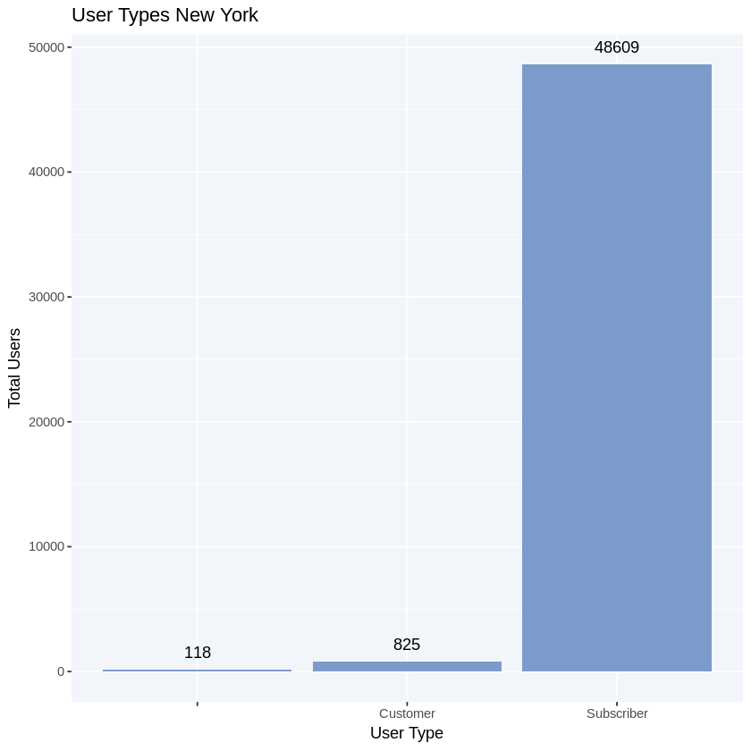

```r
ny <- na.omit(ny)
ny_users <- ggplot(data=ny, aes(x=ny$User.Type)) +
        geom_bar(stat="count", fill = "#7D9BCA") +   geom_text(
    stat = "count",
    aes(label = ..count..), vjust = -1,
  ) +
labs(x = "User Type", y = "Total Users", title = "User Types New York") +
theme(panel.background = element_rect(fill = "#f2f5f9"), text = element_text(color = "Black"))
ny_users
```

```r
table(wash$User.Type)
```

```
             Customer Subscriber
         0      23450      65600
```

```r
prop.table(table(wash$User.Type))
```

```
             Customer Subscriber
 0.0000000  0.2633352  0.7366648
```

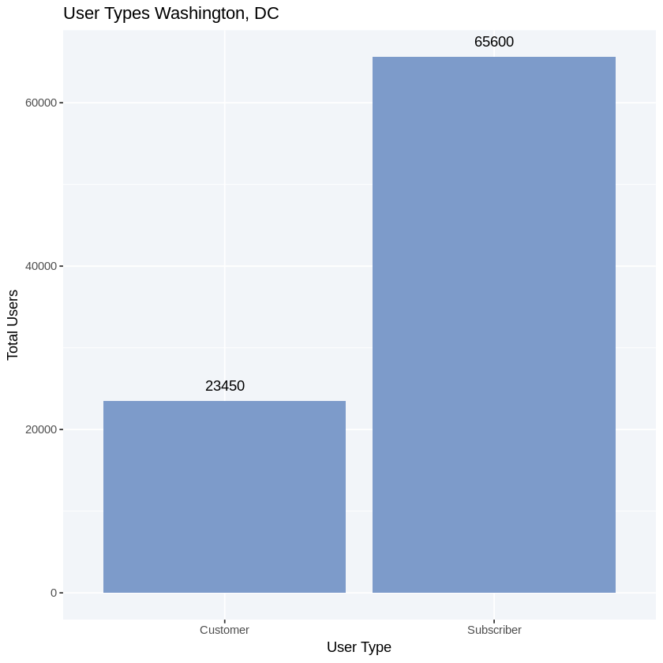

```r
wash <- na.omit(wash)

wash_users <- ggplot(data=wash, aes(x=User.Type)) +
  geom_bar(stat="count", fill = "#7D9BCA") +   geom_text(
    stat = "count",
    aes(label = ..count..), vjust = -1,
  ) +
labs(x = "User Type", y = "Total Users", title = "User Types Washington, DC") +
theme(panel.background = element_rect(fill = "#f2f5f9"), text = element_text(color = "Black"))
wash_users
```

```r
table(chi$User.Type)
```

```
             Customer Subscriber
         1       1746       6883
```

```r
prop.table(table(chi$User.Type))
```

```
                 Customer   Subscriber
0.0001158749 0.2023174971 0.7975666280
```

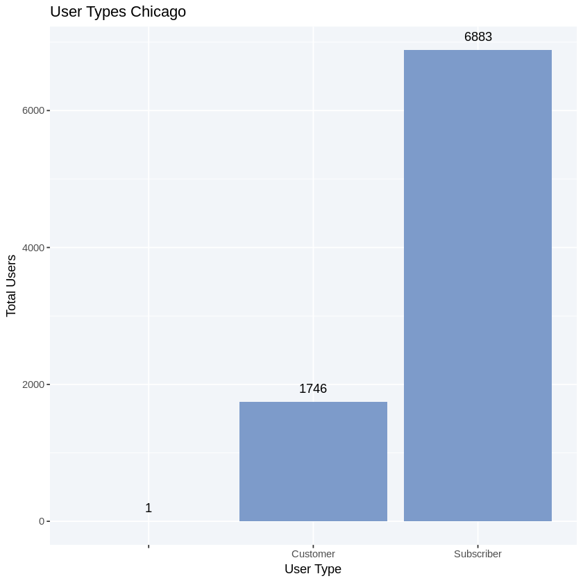

```r
chi_users <- ggplot(data=chi, aes(x=chi$User.Type)) +
        geom_bar(stat="count", fill = "#7D9BCA") +   geom_text(
    stat = "count",
    aes(label = ..count..), vjust = -1,
  ) +
labs(x = "User Type", y = "Total Users", title = "User Types Chicago") +
theme(panel.background = element_rect(fill = "#f2f5f9"), text = element_text(color = "Black"))
chi_users
```

### Question 3

What are the counts of each gender (only available for NYC and Chicago)?

```r
# Your solution code goes here
```

```r
table(ny$Gender)
```

```
       Female   Male
   193  12158  37201
```

```r
prop.table(table(ny$Gender))
```

[output not shown]

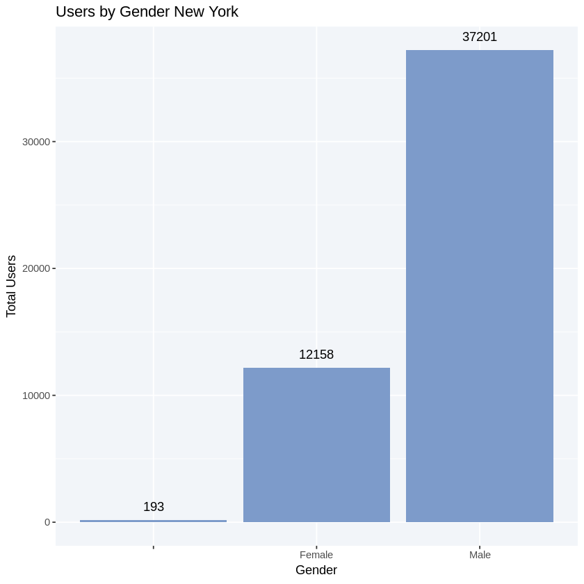

```r
ny_gender <- ggplot(data=ny, aes(x=ny$Gender)) +
        geom_bar(stat="count", fill = "#7D9BCA") +   geom_text(
    stat = "count",
    aes(label = ..count..), vjust = -1,
  ) +
labs(x = "Gender", y = "Total Users", title = "Users by Gender New York") +
theme(panel.background = element_rect(fill = "#f2f5f9"), text = element_text(color = "Black"))
ny_gender
```

```r
table(chi$Gender)
```

```
       Female   Male
  1748   1723   5159
```

```r
prop.table(table(chi$Gender))
```

```
             Female      Male
0.2025492 0.1996524 0.5977984
```

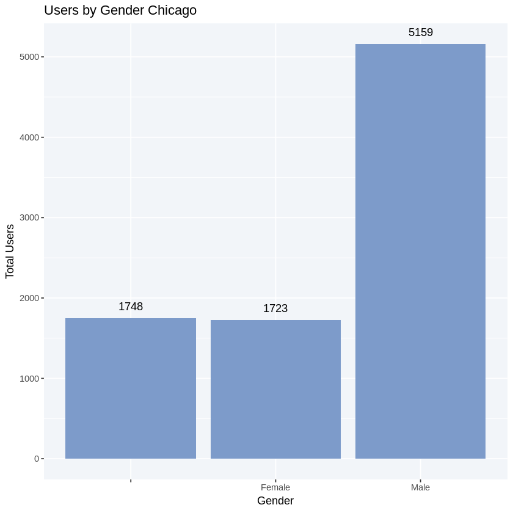

```r
chi_gender <- ggplot(data=chi, aes(x=chi$Gender)) +
        geom_bar(stat="count", fill = "#7D9BCA") +   geom_text(
    stat = "count",
    aes(label = ..count..), vjust = -1,
  ) +
labs(x = "Gender", y = "Total Users", title = "Users by Gender Chicago") +
theme(panel.background = element_rect(fill = "#f2f5f9"), text = element_text(color = "Black"))
chi_gender
```

## Finishing Up

> Congratulations! You have reached the end of the Explore Bikeshare Data Project. You should be very proud of all you have accomplished!

> **Tip**: Once you are satisfied with your work here, check over your report to make sure that it is satisfies all the areas of the [rubric](https://review.udacity.com/#!/rubrics/2508/view).

## Directions to Submit

> Before you submit your project, you need to create a .html or .pdf version of this notebook in the workspace here. To do that, run the code cell below. If it worked correctly, you should get a return code of 0, and you should see the generated .html file in the workspace directory (click on the orange Jupyter icon in the upper left).

> Alternatively, you can download this report as .html via the **File** > **Download as** submenu, and then manually upload it into the workspace directory by clicking on the orange Jupyter icon in the upper left, then using the Upload button.

> Once you've done this, you can submit your project by clicking on the "Submit Project" button in the lower right here. This will create and submit a zip file with this .ipynb doc and the .html or .pdf version you created. Congratulations!

```r
system('python -m nbconvert Explore_bikeshare_data.ipynb')
```